# Data Programming Project

Riste Kocev

# Spotify Top 50 Songs

Data Programming Project 2023

# Introduction

In this project, we will analyze the “Spotify Top 50 Songs” dataset. The dataset consists of information about the top 50 songs from Spotify playlists in various countries. We will perform data aggregation, exploratory data analysis, and visualize the data using the tidyverse approach in R.

The main objective is to gain insights into the characteristics of the top songs, such as their popularity, duration, and release date. We will also explore relationships between different variables and identify any trends or patterns.

# Presentation of the Data

Let’s start by loading the dataset and presenting the head of the dataframes, along with the data types and a brief explanation of each column.

```r
library(tidyverse)
spotify_data <- read_csv("spotify-streaming-top-50-world.csv")
head(spotify_data)
```

```
## # A tibble: 6 × 11
##   date       position song              artist popularity duration_ms album_type
##   <date>        <dbl> <chr>             <chr>       <dbl>       <dbl> <chr>
## 1 2023-05-18        1 Ella Baila Sola   Eslab…         89      165671 album
## 2 2023-05-18        2 un x100to         Grupo…         99      194563 single
## 3 2023-05-18        3 La Bebe - Remix   Yng L…         99      234352 single
## 4 2023-05-18        4 Cupid - Twin Ver. FIFTY…         97      174253 single
## 5 2023-05-18        5 Flowers           Miley…         91      200600 album
## 6 2023-05-18        6 Daylight          David…         96      212953 single
## # ℹ 4 more variables: total_tracks <dbl>, release_date <date>,
## #   is_explicit <lgl>, album_cover_url <chr>
```

The dataset contains the following columns:

- `date`: The date when the data was collected in the format “yyyy-mm-dd”.
- `position`: The position of the song in the Spotify playlist (ranging from 1 to 50).
- `song`: The name of the song.
- `artist`: The name of the artist(s) of the song. If multiple artists are involved, they are separated by “&”.
- `popularity`: The popularity metric given by Spotify’s API, indicating how popular the song is.
- `duration_ms`: The duration of the song in milliseconds.
- `album_type`: The type of album (e.g., single, album, etc.).
- `total_tracks`: The total number of tracks in the record.
- `release_date`: The date when the song was released.
- `is_explicit`: A boolean value indicating whether the song contains explicit content (True/False).
- `album_cover_url`: The URL containing the image of the album cover of the song.

Now that we have an overview of the dataset, let’s move on to aggregating the data to gain further insights.

# Aggregation of Data

For the aggregation of data, we will perform some summarization operations to obtain meaningful information. Let’s showcase at least three aggregations using the `dplyr` package.

```r
# Table 1: Average Popularity by Album Type
avg_popularity_by_album <- spotify_data %>%
  group_by(album_type) %>%
  summarise(avg_popularity = mean(popularity))

# Table 2: Total Number of Songs by Album Type
total_songs_by_album <- spotify_data %>%
  group_by(album_type) %>%
  summarise(total_songs = n())

# Table 3: Top 10 Artists with Most Songs
top_10_artists <- spotify_data %>%
  group_by(artist) %>%
  summarise(total_songs = n()) %>%
  top_n(10, total_songs) %>%
  arrange(desc(total_songs))

# Print the output tables
cat("Table 1: Average Popularity by Album Type\n")
```

```
## Table 1: Average Popularity by Album Type
```

```r
print(avg_popularity_by_album)
```

```
## # A tibble: 3 × 2
##   album_type  avg_popularity
##   <chr>                <dbl>
## 1 album                 88.6
## 2 compilation           27
## 3 single                92.2
```

```r
cat("\nTable 2: Total Number of Songs by Album Type\n")
```

```
##
## Table 2: Total Number of Songs by Album Type
```

```r
print(total_songs_by_album)
```

```
## # A tibble: 3 × 2
##   album_type  total_songs
##   <chr>             <int>
## 1 album               717
## 2 compilation           1
## 3 single              732
```

```r
cat("\nTable 3: Top 10 Artists with Most Songs\n")
```

```
##
## Table 3: Top 10 Artists with Most Songs
```

```r
print(top_10_artists)
```

```
## # A tibble: 26 × 2
##    artist                    total_songs
##    <chr>                           <int>
##  1 The Weeknd                         87
##  2 Taylor Swift                       71
##  3 Metro Boomin                       63
##  4 Miley Cyrus                        58
##  5 Arctic Monkeys                     29
##  6 David Guetta & Bebe Rexha          29
##  7 David Kushner                      29
##  8 Eslabon Armado                     29
##  9 FIFTY FIFTY                        29
## 10 Feid & Young Miko                  29
## # ℹ 16 more rows
```

# Exploratory Data Analysis

For exploratory data analysis, we will create at least three relevant and distinct ggplots to visualize different aspects of the data.

## Plot 1: Popularity Distribution

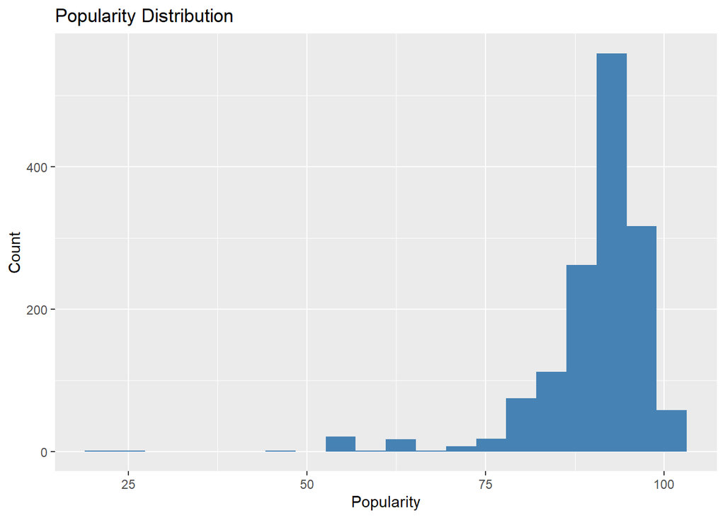

```r
popularity_distribution <- spotify_data %>%
  ggplot(aes(x = popularity)) +
  geom_histogram(fill = "steelblue", bins = 20) +
  labs(title = "Popularity Distribution",
       x = "Popularity",
       y = "Count")

popularity_distribution
```

The first plot represents the distribution of song popularity. It helps us understand the range and frequency of popularity scores among the top songs.

## Plot 2: Average Song Duration by Album Type

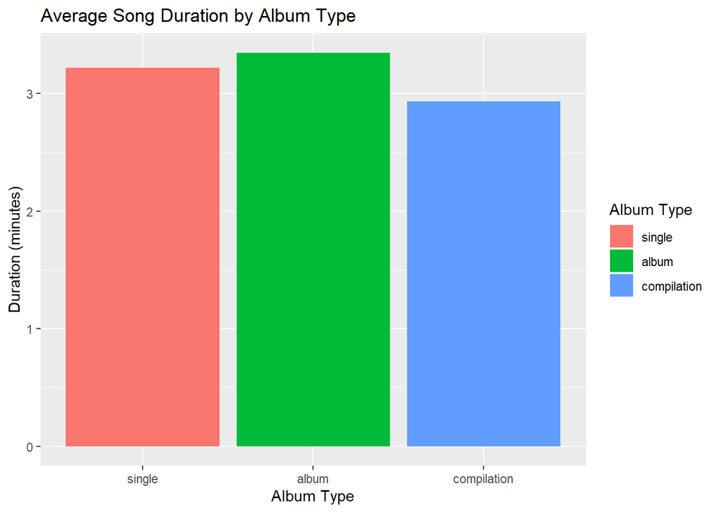

```r
avg_duration_by_album <- spotify_data %>%
  mutate(album_type = fct_infreq(album_type)) %>%
  ggplot(aes(x = album_type, y = duration_ms / 60000, fill = album_type)) +
  stat_summary(fun = mean, geom = "bar") +
  labs(title = "Average Song Duration by Album Type",
       x = "Album Type",
       y = "Duration (minutes)",
       fill = "Album Type")

avg_duration_by_album
```

The second plot illustrates the average song duration categorized by album type. It allows us to compare the average durations of songs in different album types.

## Plot 3: Song Popularity Over Time

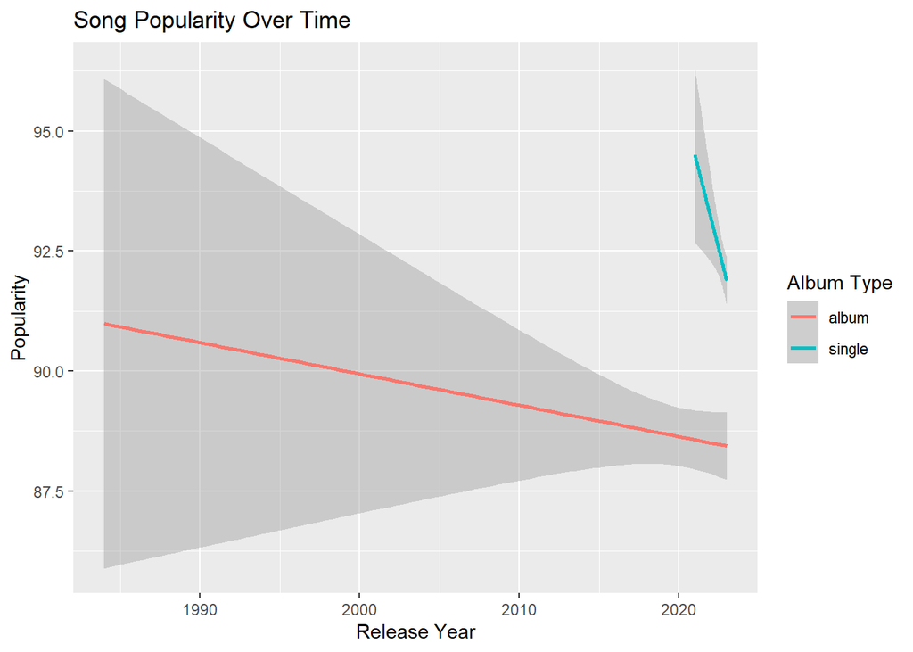

```r
song_popularity_over_time <- spotify_data %>%
  mutate(release_year = lubridate::year(release_date)) %>%
  ggplot(aes(x = release_year, y = popularity, color = album_type)) +
  geom_smooth(method = "lm") +  # Adjust the smoothing method
  labs(title = "Song Popularity Over Time",
       x = "Release Year",
       y = "Popularity",
       color = "Album Type")

song_popularity_over_time
```

The third plot showcases how song popularity has evolved over time. By plotting the trend lines for different album types, we can observe any variations in popularity over the years.

## Plot 4: Distribution of Song Popularity

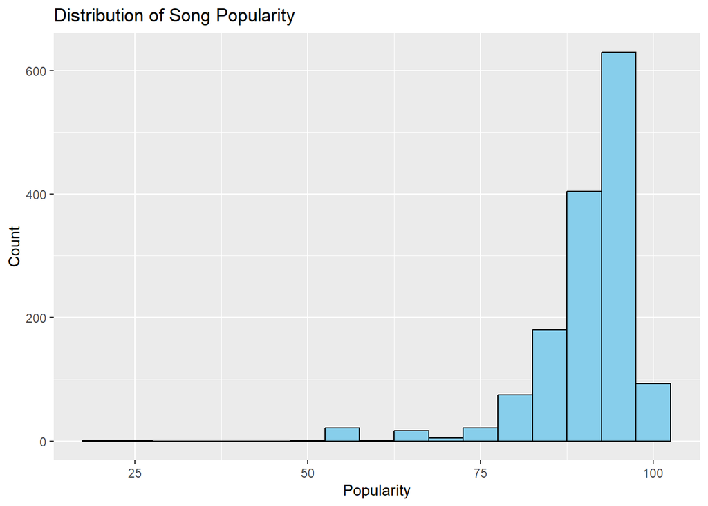

```r
# Plot 4: Distribution of Song Popularity
popularity_distribution <- spotify_data %>%
  ggplot(aes(x = popularity)) +
  geom_histogram(binwidth = 5, fill = "skyblue", color = "black") +
  labs(
    title = "Distribution of Song Popularity",
    x = "Popularity",
    y = "Count"
  )

popularity_distribution
```

In the fourth plot the `popularity_distribution` (histogram) displays the distribution of song popularity. The x-axis represents the popularity values, and the y-axis represents the count of songs falling within each popularity bin.

## Plot 5: Top 10 Artists by Total Song Duration

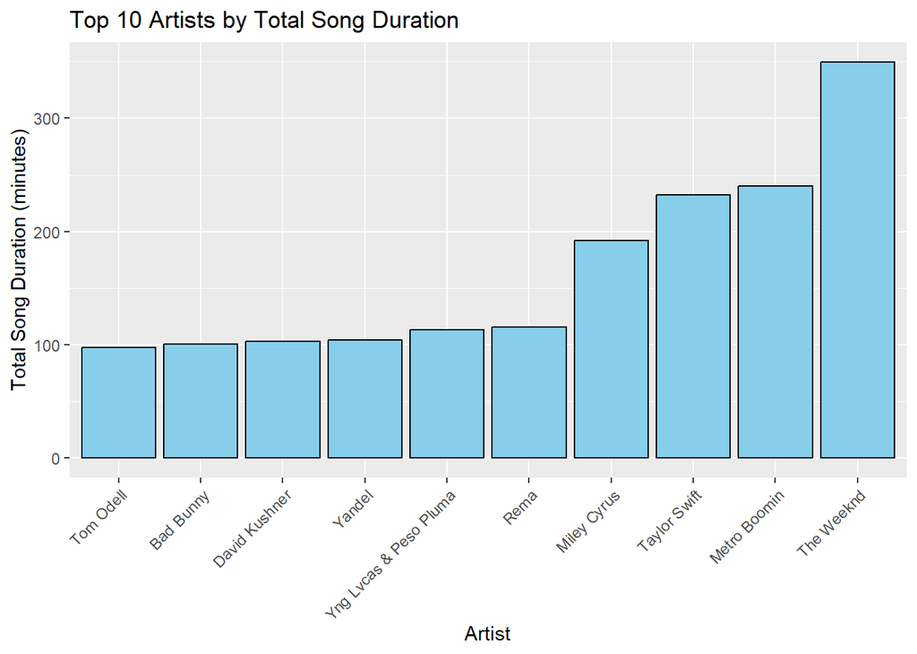

```r
top_10_artists_duration <- spotify_data %>%
  group_by(artist) %>%
  summarise(total_duration = sum(duration_ms) / 60000) %>%
  top_n(10, total_duration) %>%
  arrange(desc(total_duration)) %>%
  ggplot(aes(x = reorder(artist, total_duration), y = total_duration)) +
  geom_bar(stat = "identity", fill = "skyblue", color = "black") +
  labs(
    title = "Top 10 Artists by Total Song Duration",
    x = "Artist",
    y = "Total Song Duration (minutes)"
  ) +
  theme(axis.text.x = element_text(angle = 45, hjust = 1))

top_10_artists_duration
```

In the fifth plot there is the`top_10_artists_duration` bar chart that showcases the top 10 artists based on the total duration of their songs.The x-axis represents the artist names, and the y-axis represents the total song duration in minutes.

# Interpretation / Conclusion

These findings contribute to a better understanding of the Spotify Top 50 Songs dataset, shedding light on album types, artist contributions, song popularity, and song durations.

# References

- Dataset: [Kaggle - Spotify Top 50 Playlist Songs](https://www.kaggle.com/datasets/anxods/spotify-top-50-playlist-songs-anxods)
- Additional R packages used: `tidyverse`, `lubridate`, `glmnet`.